# Annotation in single-cell data using SSpMosaic

2025-07-30

## SSpMosaic annotation

In this tutorial we showcase how to use SSpMosaic for the annotation of single-cell data. **Before SSpMosaic annotation, the `generate_module` step should be executed on the reference dataset. If the reference dataset has multiple batches, the `generate_module` step needs to be run on each batch separately, followed by running the `network-propagation` step as a whole.**

## Package loading

```r
library(SSpMosaic)
library(clusterProfiler)
library(org.Hs.eg.db)
```

## Set the working directory

Users can replace this directory with an appropriate path when using

```r
setwd('./')
current_dir <- getwd()
result_dir <- paste0(current_dir,'/result/')
data_dir <- paste0(current_dir,'/data/')
```

## Data loading

The input data for SSpMosaic single-cell annotation is a Seurat object containing unsupervised clustering results.

The example data required to run this tutorial can be downloaded from https://drive.google.com/drive/folders/1QOKvUgN0tE068-BmedRsdqa_mz8tzwDF.

```r
seurat_object <- readRDS(paste0(data_dir,'/Inh_for_annotation.rds'))
```

## SSpMosaic metaprogram loading

Load SSpMosaic programs generated by `filter_module` on a single reference dataset or follow the tutorial `network-propagation` to generate the gene sets corresponding to the SSpMosaic metaprograms. Here we load SSpMosaic metaprograms generated from multiple batches as shown in tutorial `network-propagation`.The example metaprograms required to run this tutorial can be downloaded from https://drive.google.com/drive/folders/1QOKvUgN0tE068-BmedRsdqa_mz8tzwDF.

```r
meta_module_genes <- gene_list(paste0(data_dir,'/Inh_meta_module_genes.txt'))
```

## Transfer to Ensembl ID

Since the genes of the data to be annotated are Ensembl IDs, the SSpMosaic metaprogram will be converted to Ensembl IDs.

```r
#Initialize a list to store the SSpMosaic metaprograms in Ensembl ID
meta_module_genes_ENSEMBL <- list()
#Iterate over each SSpMosaic metaprogram
for(m in 1:length(names(meta_module_genes)))
{
  #Extract the name of the metaprogram
  n <- names(meta_module_genes)[m]
  print(n)
  #Extract the corresponding gene set of the metaprogram
  gene_names <- meta_module_genes[[n]]
  #Transfer gene symbol to Ensembl ID
  bitr_results <- bitr(gene_names, fromType="SYMBOL", toType="ENSEMBL", OrgDb="org.Hs.eg.db")
  #Generate the mapping vector from symbol to Ensembl ID
  gene_to_ensembl <- setNames(bitr_results$ENSEMBL, bitr_results$SYMBOL)
  #Generate Ensembl ID gene vector
  ensembl_ids <- sapply(gene_names, function(x) gene_to_ensembl[x])
  #Filter NA
  ensembl_ids <- ensembl_ids[!is.na(ensembl_ids)]
  #Save Ensembl ID gene vector into the list
  meta_module_genes_ENSEMBL[[n]] <- ensembl_ids
}
meta_module_genes <- meta_module_genes_ENSEMBL
```

## Weighted average score

The function `weighted_score` is used to perform a weighted average scoring for each metaprogram based on the frequency of gene occurrence in the gene set.

The parameters of `weighted_score` are as follows:

- **object**: A seurat object of single cell data.
- **meta_moudule_genes**: A list where each item is a character array storing the gene set corresponding to the SSpMosaic (meta)programs
- **normalize_method**: A string representing the normalization method, which should be selected from ‘none’, ‘zscore’, or ‘min-max’
- **assay**: A string indicating the name of assay to pull the gene expressiong data from
- **layer**: A string indicating the name of layer to fetch data from,for Seurat v5 only.
- **slot**: A string indicating the name of slot to fetch data from,for Seurat v4 only.
- **anno**: A boolean variable that specifies whether to annotate the cells with the highest-scoring meta-module,by default FALSE

```r
#Calculate weighted average score for each metaprogram
seurat_object <- weighted_score(object = seurat_object,meta_module_genes = meta_module_genes,assay = 'RNA',layer = 'data',slot = 'data',normalize_method = 'none')
```

## SSpMosaic annotation

The function `SSpMosaic_sc_annotation` is used to annotate the query single cell data,based on the weighted average scores.

The parameters of `SSpMosaic_sc_annotation` are as follows:

- **object**: A seurat object ,the return value of the `weighted_score` function
- **meta_moudule_genes**: A list where each item is a character array storing the gene set corresponding to the SSpMosaic (meta)programs; it must match the `meta_moudule_genes` parameter used in `weighted_score`.
- **cluster_col**: A string indicating the column name in the Seurat object metadata corresponding to the cell cluster assignment.
- **sd_thres**: A non-negative double that specifies the threshold for the difference between two standard deviations.
- **mean_thres**: A non-negative double,indicating the threshold of the difference between two mean values.
- **annotation_name**:A string,indicating the column to add in metadata to store the annotation information.

```r
#Run SSpMosaic annotation
res <- SSpMosaic_sc_annotation(object = seurat_object,meta_module_genes = meta_module_genes,cluster_col = "seurat_clusters")
```

## View annotation results

Draw umap plot to show SSpMosaic results

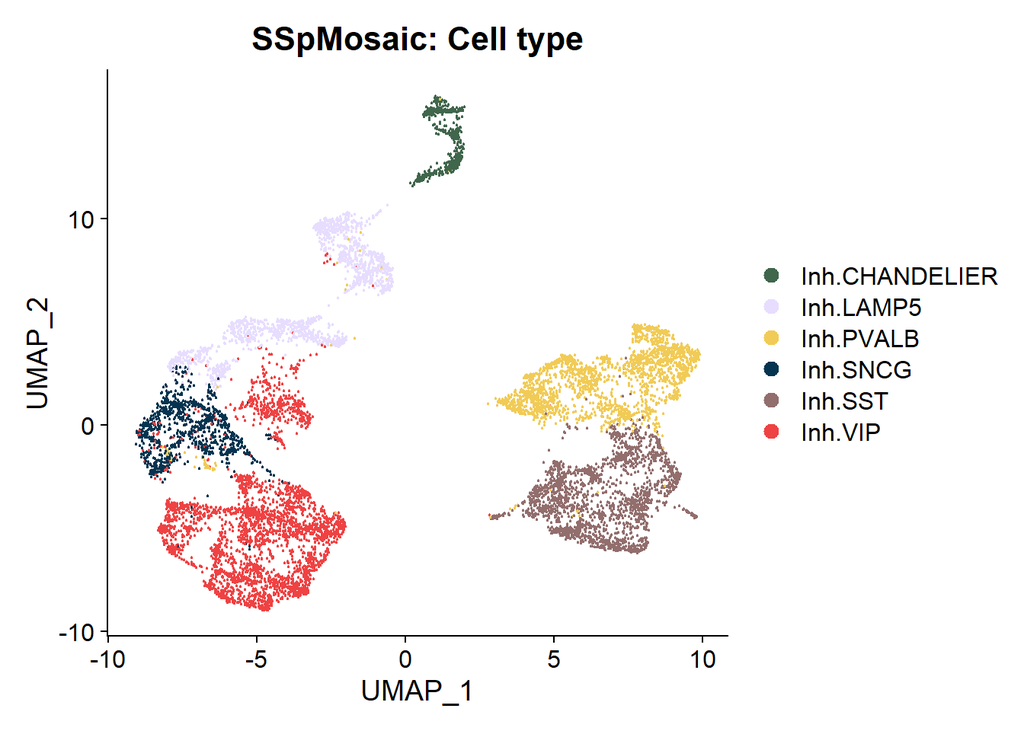

```r
#Summarize different meta modules representing the same cell type.
res[["object"]]@meta.data[["annotation"]] <- gsub('_2','',res[["object"]]@meta.data[["annotation"]])
#Specify the color for each celltype
cols <- c('#926E6D', '#F1CB56', '#E7DDFF', '#40664C', '#EF4243', '#053450')
names(cols) <- c('Inh.SST','Inh.PVALB','Inh.LAMP5','Inh.CHANDELIER','Inh.VIP','Inh.SNCG')
#Draw umap plot
DimPlot(res[["object"]],group.by = 'annotation',reduction = 'umap',cols = cols) + labs(title = "SSpMosaic: Cell type")
```